# COMPSIC 617 Spring 2019

## Homework 3

## 1. Probit Classification

### (a)

Given $Y = \begin{cases} 1 &\mbox{if } Z > 0\\ 0 &\mbox{otherwise} \end{cases}$ and $Z = \bf{x}\beta + \epsilon \ \ $, then $\mathrm{Pr}(Y=1|\mathbf{x}) = \mathrm{Pr}(Z > 0) = \mathrm{Pr}(Z = \bf{x}\beta + \epsilon > \mathrm{0})$  
$\Rightarrow \mathrm{Pr}(\bf{x}\beta + \epsilon > \mathrm{0}) =\mathrm{Pr}(\epsilon > -\bf{x}\beta) $  
Because $\epsilon$ belongs to a standard nomral $\mathcal{N}(0, 1)$, $\mathrm{Pr}(\epsilon > -\bf{x}\beta) = \mathrm{1} - \mathrm{Pr}(\epsilon <-\bf{x}\beta) = \mathrm{1} - \mathrm{\Phi(-\bf{x}\beta)} =\mathrm{\Phi(\bf{x}\beta)}$  
Therefore: $\Pr(Y=1|\bf{x}) = \mathrm{\Phi(\bf{x}\beta)}$

### (b)

$Y \sim Bernoulli(p), p = \Phi(\bf{x}\beta)： \\ $  
$f(y|\bf{x},\beta) $ $=$ ${\Phi(\bf{x}\beta)}^y{(1-\Phi(\bf{x}\beta))}^{1-y}$, for $y=0,1$

$ L(\beta) = \mathrm{Pr}(Y=y_1... Y=y_n | \beta, x_1...x_n) = \displaystyle \prod_{i=1}^N {\Phi(\bf{x_i}\beta)}^{y_i}{(1-\Phi(\bf{x_i}\beta))}^{1-y_i} \\ \begin{align} logL(\beta) &= log \displaystyle \prod_{i=1}^N {\Phi(\bf{x_i}\beta)}^{y_i}{(1-\Phi(\bf{x_i}\beta))}^{1-y_i} \\ &= \displaystyle \sum_{i=1}^N log {\Phi(\bf{x_i}\beta)}^{y_i}{(1-\Phi(\bf{x_i}\beta))}^{1-y_i} \\ &=\displaystyle \sum_{i=1}^N log {\Phi(\bf{x_i}\beta)}^{y_i} + log{(1-\Phi(\bf{x_i}\beta))}^{1-y_i}\\ &=\displaystyle \sum_{i=1}^N log {\Phi(\bf{x_i}\beta)}^{y_i} + log{(\Phi(-\bf{x_i}\beta))}^{1-y_i} \\ &=\displaystyle \sum_{i=1}^N y_i\ log {\Phi(\bf{x_i}\beta)} + {(1-y_i)} \ log{(\Phi(-\bf{x_i}\beta))} \end{align} $ </font>

### (d)

$$\frac{\partial -\log \mathcal{L}(\beta)}{\partial \beta} = -\sum_{i=1}^N y_i\frac{x_i\phi({\mathbf{x}_i}\beta)}{\Phi(\mathbf{x}_i\beta)} + (1-y_i)\frac{-x_i\phi{(\mathbf{x}_i\beta)}}{1- \Phi(\mathbf{x}_i\beta)}$$

## 2. Adaboost with $L_2$ Loss

### (a)

The LHS:  
$ \DeclareMathOperator*{\argmax}{arg\,max} \begin{align} \argmax\limits_{j=1,\dots,m} \left[-\frac{\partial}{\partial \alpha}L({\mathbf{\lambda}} + \alpha\mathbf{e}_j)\right]\biggr|_{\alpha = 0} &= \argmax\limits_{j=1,\dots,m} \left[-\frac{\partial}{\partial \alpha} \frac{1}{n}\sum_{i=1}^n [y_i - h(\mathbf{x}_i)({\mathbf{\lambda}} + \alpha\mathbf{e}_j)]^2\right]\biggr|_{\alpha = 0} \\ &=\argmax\limits_{j=1,\dots,m} \left[-\frac{2}{n}\sum_{i=1}^n [y_i - h(\mathbf{x}_i)\mathbf{({\lambda}} + \alpha\mathbf{e}_j)][-h(\mathbf{x}_i) \mathbf{e}_j]\right]\biggr|_{\alpha = 0}\\ &=\argmax\limits_{j=1,\dots,m} \left[\sum_{i=1}^n [y_i - h(\mathbf{x}_i)\mathbf{({\lambda}} + \alpha\mathbf{e}_j)]h_j(\mathbf{x}_i)\right]\biggr|_{\alpha = 0} \\ &=\argmax\limits_{j=1,\dots,m} \left[\sum_{i=1}^n [y_i - h(\mathbf{x}_i)\mathbf{{\lambda}}]h_j(\mathbf{x}_i)\right]\\ &=\argmax\limits_{j=1,\dots,m} \left[\sum_{i=1}^n y_ih_j(\mathbf{x}_i) - h_j(\mathbf{x}_i)h(\mathbf{x}_i)\mathbf{{\lambda}}\right] \\ &=\argmax\limits_{j=1,\dots,m} \left[\sum_{i=1}^n y_ih_j(\mathbf{x}_i) - \sum_{i=1}^nh_j(\mathbf{x}_i)h(\mathbf{x}_i)\mathbf{{\lambda}}\right] \end{align} $  
The RHS:  
$ \begin{align} & \ \ \ \ \ \argmax\limits_{j=1,\dots, m} h_j^T(\mathbf{X})(\mathbf{y} - H(\mathbf{X})\mathbf{\lambda})\\ &= \argmax\limits_{j=1,\dots, m} h_j^T(\mathbf{X})\mathbf{y} -h_j^T(\mathbf{X}) H(\mathbf{X})\mathbf{\lambda} \\ &=\argmax\limits_{j=1,\dots, m}\begin{bmatrix}h_j(\mathbf{x}_1) \cdots h_j(\mathbf{x}_n)\end{bmatrix} \cdot \begin{bmatrix}y_1\\\vdots\\ y_n\end{bmatrix} - \begin{bmatrix}h_j(\mathbf{x}_1) \cdots h_j(\mathbf{x}_n)\end{bmatrix} \cdot\begin{bmatrix} h_1(\mathbf{x}_1) & \dots & h_m(\mathbf{x}_1)\\ \vdots & \ddots & \vdots\\ h_1(\mathbf{x}_n) & \dots & h_m(\mathbf{x}_n) \end{bmatrix} \cdot {\lambda} \\ &=\argmax\limits_{j=1,\dots, m}( h_j(\mathbf{x}_1)y_1 + h_j(\mathbf{x}_2)y_2+ \cdots h_j(\mathbf{x}_n)y_n )- \left[h_j(\mathbf{x}_1)h_1(\mathbf{x}_1) + \cdots +h_j(\mathbf{x}_n)h_1(\mathbf{x}_n)\;, \;\;\cdots \;\;, \;h_j(\mathbf{x}_1)h_m(\mathbf{x}_1) + \cdots +h_j(\mathbf{x}_n)h_m(\mathbf{x}_n) \right ] \cdot \lambda \\ &=\argmax\limits_{j=1,\dots, m}\sum_{i=1}^n h_j(\mathbf{x}_i)y_i - \left[\sum_{i=1}^n h_j(\mathbf{x}_i)h_1(\mathbf{x_i}) \;, \;\;\cdots \;\;, \;\sum_{i=1}^n h_j(\mathbf{x}_i)h_m(\mathbf{x_i}) \right] \cdot \lambda\\ &=\argmax\limits_{j=1,\dots, m}\sum_{i=1}^n h_j(\mathbf{x}_i)y_i - \sum_{i=1}^n h_j(\mathbf{x}_i)\left[h_1(\mathbf{x_i}) \;, \;\;\cdots \;\;, \;h_m(\mathbf{x_i}) \right] \cdot \lambda \\ &=\argmax\limits_{j=1,\dots, m}\sum_{i=1}^n y_ih_j(\mathbf{x}_i) - \sum_{i=1}^n h_j(\mathbf{x}_i)h(\mathbf{x_i})\lambda \end{align} $  
Therefore, $\argmax\limits_{j=1,\dots,m} \left[-\frac{\partial}{\partial \alpha}L({\mathbf{\lambda}} + \alpha\mathbf{e}_j)\right]\biggr|_{\alpha = 0} =\argmax\limits_{j=1,\dots, m} h_j^T(\mathbf{X})(\mathbf{y} - H(\mathbf{X})\mathbf{\lambda}) $

### (b)

Let $ \frac{\partial L(\lambda + \alpha\mathbf{e}_j)}{\partial \alpha} \; \biggr|_{\alpha^{(t)}} $ = 0, solve for $\alpha^{(t)}$  
$ \begin{align} \frac{\partial L(\lambda + \alpha\mathbf{e}_j^{(t)})}{\partial \alpha} \; \biggr|_{\alpha^{(t)}} &= \frac{2}{n}\sum_{i=1}^n [y_i - h(\mathbf{x}_i)\mathbf{({\lambda}} + \alpha{\mathbf{e}_j})](-h(\mathbf{x}_i){\mathbf{e}_j} )\; \biggr|_{\alpha^{(t)}} \\ &= \frac{2}{n}\sum_{i=1}^n [y_i - h(\mathbf{x}_i)\mathbf{({\lambda}} + \alpha^{(t)} {\mathbf{e}_{j^{(t)}}})](-{h_{j^{(t)}}}(\mathbf{x}_i)) \\ &=\frac{2}{n}\sum_{i=1}^n \left[-y_i{h_{j^{(t)}}}(\mathbf{x}_i) + h(\mathbf{x}_i)\mathbf{{\lambda}}{h_{j^{(t)}}}(\mathbf{x}_i) + h(\mathbf{x}_i)\alpha^{(t)} {\mathbf{e}_{j^{(t)}}}{h_{j^{(t)}}}(\mathbf{x}_i)\right] \\ &=\frac{2}{n}(-\sum_{i=1}^n y_i{h_{j^{(t)}}}(\mathbf{x}_i) - h(\mathbf{x}_i)\mathbf{{\lambda}}{h_{j^{(t)}}}(\mathbf{x}_i) + \sum_{i=1}^n{h_{j^{(t)}}}(\mathbf{x}_i)\alpha^{(t)}{h_{j^{(t)}}}(\mathbf{x}_i)) \\ &=\frac{2}{n}(-h_{j^{(t)}}^T(\mathbf{X})(\mathbf{y} - H(\mathbf{X})\mathbf{\lambda}) + \sum_{i=1}^n{h^2_{j^{(t)}}}(\mathbf{x}_i)\alpha^{(t)}) \\ &= 0 \\ \end{align} \\ \sum_{i=1}^n{h^2_{j^{(t)}}}(\mathbf{x}_i)\alpha^{(t)} = h_{j^{(t)}}^T(\mathbf{X})(\mathbf{y} - H(\mathbf{X})\mathbf{\lambda}) \\ \alpha^{(t)} = \frac{h_{j^{(t)}}^T(\mathbf{X})(\mathbf{y} - H(\mathbf{X})\mathbf{\lambda})}{\sum_{i=1}^n{h^2_{j^{(t)}}}(\mathbf{x}_i)} $

### (c)

Given training data $D = {(x_i, y_i)}^n_{i=1}$ and maximum number of iterations T  
Initialize weights: $\boldsymbol\lambda_1 = \mathbf{0}$  
$\textbf{For } t=1, ... , T \textbf{ do:}$  
$j_t \in \argmax\limits_{j=1,\dots, m} h_j^T(\mathbf{X})(\mathbf{y} - H(\mathbf{X})\mathbf{\lambda}) $  
compute for the coefficient: $ \alpha^{(t)} = \frac{h_{j^{(t)}}^T(\mathbf{X})(\mathbf{y} - H(\mathbf{X})\mathbf{\lambda})}{\sum_{i=1}^n{h^2_{j^{(t)}}}(\mathbf{x}_i)} $  
update the weights for classifier: $\lambda_{t+1} = \lambda_{t} + \alpha \mathbf{e}_{jt}$  
$\textbf{end for}$  
output the $\lambda h(x_i) = \sum_{t=1}^T\frac{h_{j^{(t)}}^T(\mathbf{X})(\mathbf{y} - H(\mathbf{X})\mathbf{\lambda})}{\sum_{i=1}^n{h^2_{j^{(t)}}}(\mathbf{x}_i)}h_{j^{(t)}}(x_i) $

## 3.Comparing AdaBoost and Logistic Regression

### (a)

```python
import pandas as pd
import numpy as np
training_data = pd.read_csv('house_votes_84_train.csv').values
testing_data = pd.read_csv('house_votes_84_test.csv').values
```

```python
class Adaboost:
    def __init__(self, training_data , testing_data):
        self.label = training_data.T[0]
        self.data = training_data[:,1:]
        self.M = np.zeros((self.data.shape[0], self.data.shape[1]))   #matrix of margin for a weak classifier
        for i in range(self.data.shape[1]):
            self.M[:, i] = self.label * self.data[:,i]
        self.lambda_ = np.zeros(self.data.shape[1])
        self.test_data = testing_data[:,1:]
        self.test_label = testing_data.T[0]

    def train_adaboost(self):
        d= np.ones(self.data.shape[0])/self.data.shape[0]
        pre_error = 0;
        error = 1;
        error_index = []
        Flag = False
        count =1
        while (abs(error - pre_error )> 10**-5):
            if Flag:
                pre_error = error
            error = 0
            j = np.argmax(np.dot(d.T,self.M))
            for i in range(len(self.M.T[j])):
                if self.M.T[j][i] < 0:
                    error += d[i]
                    error_index.append(i)
            for k in range(len(d)):
                if k in error_index:
                    d[k] = 1/2*(d[k]/error)
                else:
                    d[k] = 1/2*(d[k]/(1-error))
            alpha = 1/2*np.log((1-error) / error)
            self.lambda_[j]+=alpha
            error_index.clear()
            Flag = True

    def predict(self,features):
        return np.sign(np.dot(self.lambda_, features))

    def accuracy(self):
        sum = 0;
        for x in range(self.test_data.shape[0]):
            if self.predict(self.test_data[x]) * self.test_label[x] > 0:
                sum += 1
        print(sum/self.test_data.shape[0])
        return sum/self.test_data.shape[0]
```

### (b)

```python
from scipy.optimize import minimize
from math import log
import sys
class LR:
    def __init__(self, training_data):
        self.label = training_data.T[0]
        self.data = training_data[:,1:]
        self.lambda_ = np.zeros(self.data.shape[1])
    def loss_fun(self, Lambda):
        sum = 0
        for i in range(self.data.shape[0]):
            sum += log(1+np.exp(-self.label[i] * np.dot(Lambda.T,self.data[i])))
        return sum
    def maximization(self):
        self.lambda_ = minimize(self.loss_fun,self.lambda_, method='SLSQP', tol =1e-6).x
    def logistic_function(self,features):
        probability = np.exp(np.dot(self.lambda_.T,features))/(1+np.exp(np.dot(self.lambda_.T,features)))
        return probability
    def predict(self,features):
        probability_1 = self.logistic_function(features)
        if probability_1 < 0.5:
            return -1
        else:
            return 1
```

```python
##Notice: functions for calculating LR accuracy and making predictions for large dataset  They are not used for LR
#impelementation!
def LR_accuracy(real_label, predict_label):
    misclassified_total = 0
    for i in real_label*np.array(predict_label):
        if i < 0:
            misclassified_total+=1
    print(1-misclassified_total/len(real_label))
    return 1-misclassified_total/len(real_label)

def predict_dataset(dataset, model):
    predicted_label = []
    for i in range(dataset[:,1:].shape[0]):
        label1 = model.predict(dataset[:,1:][i])
        predicted_label.append(label1)
    return predicted_label
```

### (c)

```python
### adaboost train on training data set; test on both training and testing set
Adaboost_training_object = Adaboost(training_data, training_data)
Adaboost_training_object.train_adaboost()
print('The training accuracy for adaboost is ',end='')
_ = Adaboost_training_object.accuracy()
Adaboost_testing_object = Adaboost(training_data, testing_data)
Adaboost_testing_object.train_adaboost()
print('The testing accuracy for adaboost is ',end='')
_ = Adaboost_testing_object.accuracy()
ada_prediction_testset = predict_dataset(testing_data,Adaboost_testing_object)
```

```
The training accuracy for adaboost is 0.9428571428571428
The testing accuracy for adaboost is 0.98
```

```python
# same thing on the LR
Logistic_object = LR(training_data)
Logistic_object.maximization()
training_predict_label = predict_dataset(training_data, Logistic_object)
print("The training accuracy for LR is ", end='')
_=LR_accuracy(training_data.T[0], training_predict_label)
testing_predict_label = predict_dataset(testing_data,Logistic_object)
print("The testing accuracy for LR is ", end='')
_=LR_accuracy(testing_data.T[0], testing_predict_label)
```

```
The training accuracy for LR is 0.9636363636363636
The testing accuracy for LR is 0.94
```

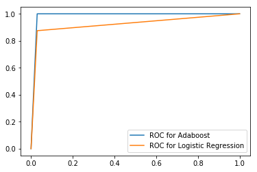

```python
## ROC curves
import sklearn.metrics
import matplotlib.pyplot as plt
fpr_ad,tpr_ad,_ = sklearn.metrics.roc_curve(testing_data.T[0], ada_prediction_testset)
fpr_lr,tpr_lr,_ = sklearn.metrics.roc_curve(testing_data.T[0] , testing_predict_label)
plt.plot(fpr_ad,tpr_ad,label = "ROC for Adaboost")
plt.plot(fpr_lr,tpr_lr,label = "ROC for Logistic Regression")
plt.legend()
plt.show()
```

The logistic regression has higher training accuracy but we care more about the test accuracy which the adaboost is 4% accuracy higher than logistic regression. Therefore, given the test set, adaboost outperforms the logsitic regression.

```python
### cross validation for adaboost
from sklearn.model_selection import train_test_split, KFold
from statistics import stdev, mean
cv= KFold(n_splits=10)
fold_number =1
accuracy_list =[]
print('AdaBoost for cross validation:')
for train, test in cv.split(training_data):
    Adaboost_object = Adaboost(training_data[train],training_data[test])
    Adaboost_object.train_adaboost()
    print('Accuracy for fold' + str(fold_number) + ':   ', end='')
    accuracy = Adaboost_object.accuracy()
    print('')
    accuracy_list.append(accuracy)
    fold_number +=1
mean_Ada = mean(accuracy_list)
std_Ada =stdev(accuracy_list)
print('The average accuracy for adaboost is', mean_Ada)
print('The stardard deviation for adaboost is', std_Ada)
```

```
AdaBoost for cross validation:
Accuracy for fold1:   0.9487179487179487

Accuracy for fold2:   0.9487179487179487

Accuracy for fold3:   0.9743589743589743

Accuracy for fold4:   0.9487179487179487

Accuracy for fold5:   0.9743589743589743

Accuracy for fold6:   0.9473684210526315

Accuracy for fold7:   0.9473684210526315

Accuracy for fold8:   0.9736842105263158

Accuracy for fold9:   0.7894736842105263

Accuracy for fold10:   0.9736842105263158

The average accuracy for adaboost is 0.9426450742240216
The stardard deviation for adaboost is 0.05533246287605921
```

```python
### cross validation  for LR
fold_number =1
accuracy_list2=[]
print('Logisitic Regression for cross validation:')
for train, test in cv.split(training_data):
    LR_classifier = LR(training_data[train])
    LR_classifier.maximization()
    LR_predicted_labels = predict_dataset(training_data[test], LR_classifier)
    print('Accuracy for fold'+ str(fold_number) + ':  ', end='')
    accuracy = LR_accuracy(training_data[test].T[0], LR_predicted_labels)
    print('')
    accuracy_list2.append(accuracy)
    fold_number +=1

mean_LR = mean(accuracy_list2)
std_LR =stdev(accuracy_list2)
print('The average accuracy for logistic regression is', mean_LR)
print('The stardard deviation for logistic regression is', std_LR)
```

```
Logisitic Regression for cross validation:
Accuracy for fold1:  0.9743589743589743

Accuracy for fold2:  0.9743589743589743

Accuracy for fold3:  0.9487179487179487

Accuracy for fold4:  0.9487179487179487

Accuracy for fold5:  0.9487179487179487

Accuracy for fold6:  0.9473684210526316

Accuracy for fold7:  0.9736842105263158

Accuracy for fold8:  0.8947368421052632

Accuracy for fold9:  0.8421052631578947

Accuracy for fold10:  0.9473684210526316

The average accuracy for logistic regression is 0.9400134952766531
The stardard deviation for logistic regression is 0.041452021216918246
```

### (d)

```python
# variable importance. randomly permute a feature on the test set and look into the accuracy change
# adaboost
testing_dataframe =  pd.read_csv('house_votes_84_test.csv')
original_dataframe = testing_dataframe.copy(deep=True)
column_names =list(testing_dataframe)
print('The Testing accuracy with permuted features for Adaboost')
for name in column_names[1:]:
    testing_dataframe[name] = np.random.permutation(testing_dataframe[name])
    test_new_data = testing_dataframe.values
    Adaboost_permuted_object = Adaboost(training_data, test_new_data)
    print(name + ': ',end='')
    Adaboost_permuted_object.train_adaboost()
    _ = Adaboost_permuted_object.accuracy()
    testing_dataframe=original_dataframe.copy(deep=True)
```

```
The Testing accuracy with permuted features for Adaboost
bill_1: 0.98
bill_2: 0.98
bill_3: 0.98
bill_4: 0.62
bill_5: 0.96
bill_6: 0.98
bill_7: 0.98
bill_8: 0.98
bill_9: 0.98
bill_10: 0.98
bill_11: 0.98
bill_12: 0.96
bill_13: 0.98
bill_14: 0.98
bill_15: 0.98
bill_16: 0.98
```

```python
# same thing for the LR
testing_dataframe =  pd.read_csv('house_votes_84_test.csv')
original_dataframe = testing_dataframe.copy(deep=True)
column_names =list(testing_dataframe)
print("The testing accuracy with permuted features for Logistic Regression")
for name in column_names[1:]:
    testing_dataframe[name] = np.random.permutation(testing_dataframe[name])
    test_new_data = testing_dataframe.values
    Logistic_model = LR(training_data)
    Logistic_model.maximization()
    testing_predict_label = predict_dataset(test_new_data,Logistic_model)
    print(name + ': ', end='')
    LR_accuracy(test_new_data.T[0], testing_predict_label)
    testing_dataframe=original_dataframe.copy(deep=True)
```

```
The testing accuracy with permuted features for Logistic Regression
bill_1: 0.96
bill_2: 0.94
bill_3: 0.9
bill_4: 0.62
bill_5: 0.94
bill_6: 0.98
bill_7: 0.96
bill_8: 0.92
bill_9: 0.94
bill_10: 0.96
bill_11: 0.94
bill_12: 0.96
bill_13: 0.96
bill_14: 0.96
bill_15: 0.94
bill_16: 0.94
```